# NBA Daily Fantasy Exploration

Ian Whitestone

## Table of Contents

- Introduction
- Data Import & Cleaning
- Feature Engineering
- Univariate Analysis
- Bivariate Analysis
- Multivariate Analysis
- Final Plots and Summary
- Reflection

## Introduction

Daily fantasy sports (DFS) are a subset of fantasy sports, where participants construct lineups based on the games occuring on a given day [https://en.wikipedia.org/wiki/Daily_fantasy_sports]. Lineups are subject to various constraints, such as a salary cap and having a minimum number of players at each position. As with other fantasy sports, player’s fantasy points are based on their actual performance in real life. As a result, a key component of being a successful DFS player is the ability to project a player’s total points for a given night.

This study focuses on the NBA DFS, with a particular emphasis on examining factors that influence a player’s score. The NBA data used in the study is sourced from Erik Berg’s API [https://erikberg.com/api]. The study covers NBA data from the 2012-2013 season, up until the 2015-2016 season. Fantasy points are calculated using Fanduel’s scoring system, described below. Unlike other sports, all positions in the NBA are scored using the same system.

- 3-pt FG = 3pts
- 2-pt FG = 2pts
- FT = 1pt
- Rebound = 1.2pts
- Assist = 1.5pts
- Block = 2pts
- Steal = 2pts
- Turnover = -1pt

Source: https://www.fanduel.com/rules

## Data Import & Cleaning

Two csv files were created using the NBA data API. The player_data file contains a record for each player that recorded any statistics during a game. The event data table contains a record for each game, identified by a unique gameID. This gameID can be used to join the two data sources.

Before performing producing any plots or analysis, the data is imported and cleaned.

```r
##import packages
library(data.table)
library(dplyr)
library(dtplyr)
library(tidyr)
library(ggplot2)
source("dlin.R")
library(RColorBrewer)
library(reshape2)
library(corrplot)
source("roll_variable.R")
library(RcppRoll)
library(rms)
source("multiplot.R")
library(plyr)

palette = brewer.pal("YlGnBu", n=9)

##read in data
player_data = read.csv("data/player_data.csv")
event_data = read.csv("data/event_data.csv")

##convert to data.tables
event_data = as.data.table(event_data)
player_data = as.data.table(player_data)

#rename and drop unnecessary columns
player_data[ ,c("X","sport") := NULL]
event_data[,X:=NULL]
setnames(player_data,old = c('X3FGA','X3FGM'),new = c('3FGA','3FGM'))

#get rid of duplicate rows in event_data
setkey(event_data,gameID)
event_data = unique(event_data)

#convert positions coded as 'F' to 'SF', 'G' to 'SG'
player_data[position == 'F',position:= 'SF']
player_data[position == 'G',position:= 'SG']
```

## Feature Engineering

NOTE: this section is not required as part of the final project but was included for reference as these engineered variables are included in the EDA.

Creating powerful predictions relies not only on a good model, but significant features that represent underlying effects.

As the underlying data contains base-level statistics, the first step involves creating a variable for the Fanduel fantasy points. Other data cleaning and merging steps are documented below.

```r
require(dplyr)
##calculate fanduel points
player_data[,fd:= 3*`3FGM`+2*(FGM-`3FGM`)+1*FTM+1.2*rebounds+1.5*assists+2*blocks+2*steals-1*turnovers]

##create a seaosn variable that can be used to distinguish between different seasons
player_data[,date:=as.Date(date)] ##convert string date to actual date
player_data[,date_num:=as.numeric(date)]
player_data[,season_code:=20122013]
player_data[date >= '2013-10-28' & date <= '2014-06-16', season_code:= 20132014]
player_data[date >= '2014-10-28' & date <= '2015-06-16', season_code:= 20142015]
player_data[date >= '2015-10-27' & date <= '2016-06-19', season_code:= 20152016]

event_data = event_data %>% join(player_data[,.N,by=.(gameID,date)][,.(gameID,date)])

event_data[,season_code:=20122013]
event_data[date >= '2013-10-28' & date <= '2014-06-16', season_code:=20132014]
event_data[date >= '2014-10-28' & date <= '2015-06-16', season_code:=20142015]
event_data[date >= '2015-10-27' & date <= '2016-06-19', season_code:=20152016]
##filter out players who didnt play
player_data = filter(player_data,minutes > 0)

##get team info
team_data=event_data[,.(gameID,home_team,away_team)]
setkey(player_data,gameID)
setkey(team_data,gameID)
player_data = player_data[team_data,nomatch = 0] ##merge the team data to the player_data table

##create home/away variable
player_data[,homeaway:= 1]
player_data[team==away_team,homeaway:= 0]
```

Next, a function is created to calculate rolling averages for any statistic. The function takes in a data frame, a target field to calculate the rollign averages for, and a window variable in the form seq(starting_window,max_window,increment).

```r
roll_variable_mean = function(d, target, windows) {
  require(dplyr)
  require(lazyeval)

  exprl = list()
  i = 1

  for (x in windows) {
    exprl[[i]] = interp(~ lag(roll_mean(tar, w, align = 'right', fill = NA), 1), tar=as.name(target), w=x)
    i = i + 1
  }
  names = paste(target, windows, sep="_")
  exprl = setNames(exprl, names)

  d = mutate_(d, .dots = exprl)

  for (n in 2:length(names)) {
    expr = interp(~ ifelse(is.na(long), short, long), long=as.name(names[n]), short=as.name(names[n-1]))
    exprl = setNames(list(expr), names[n])
    d = mutate_(d, .dots = exprl)
  }

  return(d)
}



##add rolling variables
window_size = seq(5,55,10)
player_data = player_data %>% group_by(player) %>% arrange(date) %>% roll_variable_mean(., 'fd', window_size)
player_data = player_data %>% group_by(player) %>% arrange(date) %>% roll_variable_mean(., 'minutes', window_size)
player_data = player_data %>% group_by(player) %>% arrange(date) %>% roll_variable_mean(., 'FGA', window_size)
player_data = player_data %>% group_by(player) %>% arrange(date) %>% roll_variable_mean(., 'FTA', window_size)


window_size = seq(1,3,1)
player_data = player_data %>% group_by(player) %>% arrange(date) %>% roll_variable_mean(., 'fd', window_size)
player_data = player_data %>% group_by(player) %>% arrange(date) %>% roll_variable_mean(., 'minutes', window_size)
player_data = player_data %>% group_by(player) %>% arrange(date) %>% roll_variable_mean(., 'FGA', window_size)
player_data = player_data %>% group_by(player) %>% arrange(date) %>% roll_variable_mean(., 'FTA', window_size)
```

A practical hypothesis is that players/teams that are playing multiple games in a row will perform worse as a result of fatigue. To test this hypothesis, a binary back-to-back feature is created which signals if the team is playing a back-to-back game. A variable is also created to signal if the team’s opponent is playing a back-to-back game.

```r
##BACK TO BACK GAME VARIABLE
days_rest = player_data[,.N,by = .(team,date_num)][,.(team,date_num)][order(team,date_num)]
days_rest$date_diff = ave(days_rest$date_num, days_rest$team, FUN = function(x) c(10, diff(x)))
days_rest$b2b = ifelse(days_rest$date_diff == 1,1,0)

##add opponent field
player_data[,opponent:= home_team]
player_data[team == home_team,opponent:= away_team]

##join b2b,opp_b2b
setkey(player_data,team,date_num)
setkey(days_rest,team,date_num)
player_data = player_data[days_rest[,.(team,date_num,b2b)],nomatch = 0]

days_rest[,opp_b2b:= b2b][,b2b:= NULL]
setkey(player_data,opponent,date_num)
player_data = player_data[days_rest[,.(team,date_num,opp_b2b)],nomatch = 0]
```

In order to calculate team based statistics, the event_data table must be manipulated to have one record per team per game.

```r
###TEAM BASED DATA
##currently the event data table has one record per game, with statistics for each team
colnames(event_data)
```

```
##  [1] "attendance"     "away_3FGA"      "away_3FGM"      "away_FGA"
##  [5] "away_FGM"       "away_FTA"       "away_FTM"       "away_Q1"
##  [9] "away_Q2"        "away_Q3"        "away_Q4"        "away_Q5"
## [13] "away_Q6"        "away_Q7"        "away_Q8"        "away_assists"
## [17] "away_blocks"    "away_fouls"     "away_points"    "away_rebounds"
## [21] "away_steals"    "away_team"      "away_turnovers" "duration"
## [25] "gameID"         "home_3FGA"      "home_3FGM"      "home_FGA"
## [29] "home_FGM"       "home_FTA"       "home_FTM"       "home_Q1"
## [33] "home_Q2"        "home_Q3"        "home_Q4"        "home_Q5"
## [37] "home_Q6"        "home_Q7"        "home_Q8"        "home_assists"
## [41] "home_blocks"    "home_fouls"     "home_points"    "home_rebounds"
## [45] "home_steals"    "home_team"      "home_turnovers" "official_1"
## [49] "official_2"     "official_3"     "official_4"     "season_type"
## [53] "date"           "season_code"
```

As shown in the column names of event_data, team variables are preceded by ‘home_’ or ‘away_’. After splitting the table into one record per team per game, these variable names must be standardized by removing the “home/away” pre-name.

```r
##calculate final scores for each game
event_data[,home_score:= sum(home_Q1,home_Q2,home_Q3,home_Q4,home_Q5,home_Q6,home_Q7,home_Q8,na.rm= TRUE),
           by = 1:NROW(event_data)]
event_data[,away_score:=sum(away_Q1,away_Q2,away_Q3,away_Q4,away_Q5,away_Q6,away_Q7,away_Q8,na.rm= TRUE),
           by = 1:NROW(event_data)]

##to calculate team based statistics, a data frame/table with 2 records per game -
##[cont'd] one for each team, is ideal
##the code below splits the event_data table into two tables, one for each team,
##[cont'd] standardizes the variable names, and then joins the two tables back together
team_variables = c('3FGA','3FGM','FGM','FGA','FTA','FTM',
                  'Q1','Q2','Q3','Q4','Q5','Q6','Q7',
                  'Q8','assists','blocks','fouls',
                  'points','rebounds','steals','turnovers')

away_variables = paste0('away_',team_variables)
home_variables = paste0('home_',team_variables)

##data table for the home team of each game
event_data_1 = event_data[,team:= home_team][,setdiff(colnames(event_data),away_variables),with = FALSE]
##data table for hte away team of each game
event_data_2 = event_data[,team:= away_team][,setdiff(colnames(event_data),home_variables),with = FALSE]

##change the column names to generic names (i.e. away_FGM --> FGM,home_FTA --> FTA)
setnames(event_data_1,old = home_variables,new = team_variables)
setnames(event_data_2,old = away_variables,new = team_variables)

##join the two tables back together
team_data = rbind(event_data_1,event_data_2)
```

Using the new team_data table, team based features can be calculated. The total FD points for each team and their opponent are calculated below. These features are then merged back to the player_data table.

```r
##add date to team_data
setkey(team_data,gameID)
setkey(player_data,gameID)
team_data= team_data[player_data[,.N,by = .(gameID,date_num)][,.(gameID,date_num)],nomatch = 0][order(date_num)]

##define opponent in team_data table
team_data[,opponent:= home_team]
team_data[team == home_team,opponent:= away_team]

###team total FD points
team_tot_fd = player_data[,.(team_fd = sum(fd)),by = .(gameID,team)]
setkey(team_tot_fd,gameID,team)
setkey(player_data,gameID,team)
setkey(team_data,gameID,team)
player_data = player_data[team_tot_fd,nomatch = 0]
team_data = team_data[team_tot_fd,nomatch = 0]

###opponent total FD points
team_tot_fd[,`:=` (opponent = team, team = NULL,opp_fd = team_fd,team_fd = NULL)]
setkey(team_tot_fd,gameID,opponent)
setkey(player_data,gameID,opponent)
setkey(team_data,gameID,opponent)
player_data = player_data[team_tot_fd,nomatch = 0]
team_data = team_data[team_tot_fd,nomatch = 0]
```

Another potentially powerful feature is the amount of FD points a team gives up to certain positions. For example, if a team has weak defense against centers/power forwards, it should be reflected in how many FD points they give up to the opposing teams centers/PFs (on average).

The code below aggregates the FD points by game,team and position. These results are then joined back to team_data, and computed for the opponents. Rolling averages are then calculated, and finally merged back to player_data.

where the last three fields are the average FD points given up by Boston to opposing teams, C/PFs, and PG/SG/SFs respectively.

```r
##position points summary
##calculate the total FD points for each team by position
##in some cases, teams played w/o a center. for those, use the post statistic (p_fd)
posn_sum = player_data[,.(posn_points = sum(fd)),by = .(gameID,team,position)]
posn_sum = posn_sum[,.(pg_fd = sum(ifelse(position == 'PG',posn_points,0)),
                     sg_fd = sum(ifelse(position == 'SG',posn_points,0)),
                     sf_fd = sum(ifelse(position == 'SF',posn_points,0)),
                     pf_fd = sum(ifelse(position == 'PF',posn_points,0)),
                     c_fd = sum(ifelse(position == 'C',posn_points,0)),
                     g_fd = sum(ifelse(position %in% c('PG','SG','SF'),posn_points,0)),
                     p_fd = sum(ifelse(position %in% c('PF','C'),posn_points,0))),
                     by = .(gameID,team)]


##merge positional points with team_data
setkey(posn_sum,gameID,team)
setkey(team_data,gameID,team)
team_data=team_data[posn_sum,nomatch=0]

##get team opponent data
team_data_opp = team_data[,.(gameID,team,pg_fd,sg_fd,sf_fd,pf_fd,c_fd,g_fd,p_fd,team_fd)]
setnames(team_data_opp,old = c("team","pg_fd","sg_fd","sf_fd","pf_fd","c_fd","g_fd","p_fd","team_fd"),
         new = c("opponent","opp_pg_fd","opp_sg_fd","opp_sf_fd","opp_pf_fd","opp_c_fd","opp_g_fd",
                 "opp_p_fd","opp_fd"))

setkey(team_data_opp,gameID,opponent)
team_data = team_data[team_data_opp,nomatch = 0]

##rolling team statistics
##the following stat describes how many fantasy points a team has been giving up to opposing teams,
##...[cont'd] expressed as rolling averages over the last X games
team_data=team_data %>% group_by(team) %>% arrange(date_num) %>% roll_variable_mean(., 'opp_fd', window_size)
team_data=team_data %>% group_by(team) %>% arrange(date_num) %>% roll_variable_mean(., 'opp_g_fd', window_size)
team_data=team_data %>% group_by(team) %>% arrange(date_num) %>% roll_variable_mean(., 'opp_p_fd', window_size)

##join these features to player_data
##join team_data "team" on player_data "opponent"
rolling_team_variables = colnames(team_data)[grepl('fd_\\w*\\d', colnames(team_data))]
player_data = merge(player_data, team_data[,append(rolling_team_variables,c("gameID","team")),with = FALSE],
                  by.x = c('gameID','opponent'), by.y = c('gameID','team'), all = FALSE)
```

## Univariate Analysis

# What is the structure of your dataset?

# What is/are the main feature(s) of interest in your dataset?

# What other features in the dataset do you think will help support your investigation into your feature(s) of interest?

# Did you create any new variables from existing variables in the dataset?

# –> could look at distrbn of home/away for sanity check

# Of the features you investigated, were there any unusual distributions? Did you perform any operations on the data to tidy, adjust, or change the form of the data? If so, why did you do this?

```r
glimpse(player_data)
```

```
## Observations: 103,233
## Variables: 76
## $ gameID      <fctr> 20121030-boston-celtics-at-miami-heat, 20121030-b...
## $ opponent    <fctr> BOS, BOS, BOS, BOS, BOS, BOS, BOS, BOS, BOS, BOS,...
## $ 3FGA        <int> 1, 1, 0, 3, 4, 3, 2, 0, 0, 2, 2, 4, 0, 0, 1, 3, 0,...
## $ 3FGM        <int> 0, 0, 0, 2, 2, 2, 1, 0, 0, 1, 0, 2, 0, 0, 1, 0, 0,...
## $ FGA         <int> 15, 7, 22, 4, 16, 7, 5, 1, 0, 2, 14, 15, 8, 11, 6,...
## $ FGM         <int> 8, 3, 10, 2, 10, 5, 4, 0, 0, 1, 9, 6, 4, 6, 5, 2, ...
## $ FTA         <int> 4, 2, 11, 0, 5, 8, 2, 0, 0, 0, 4, 9, 1, 4, 0, 4, 4...
## $ FTM         <int> 3, 2, 9, 0, 4, 7, 1, 0, 0, 0, 2, 9, 1, 3, 0, 4, 3,...
## $ assists     <int> 1, 11, 4, 1, 3, 2, 1, 0, 1, 1, 13, 5, 2, 1, 1, 1, ...
## $ blocks      <int> 3, 0, 1, 0, 0, 0, 1, 0, 0, 0, 0, 0, 2, 0, 0, 0, 0,...
## $ date        <date> 2012-10-30, 2012-10-30, 2012-10-30, 2012-10-30, 2...
## $ fouls       <int> 3, 3, 3, 3, 2, 1, 1, 1, 1, 2, 4, 3, 4, 2, 5, 3, 0,...
## $ minutes     <int> 37, 36, 35, 29, 29, 31, 19, 11, 7, 6, 44, 41, 32, ...
```

[output cut: 63 more lines]

A quick glimpse at the player data table reveals that most variables either continuous integers or doubles. Most of the text based variables, such as team or name, are factors. All of the rolling time-window variables appear to be “NA”, however, this is due to the ordering of the data. For example, there are not enough games at the beginning to compute a 15 day average.

```
##                                                 gameID
##  20151206-los-angeles-lakers-at-detroit-pistons    :    52
##  20151206-golden-state-warriors-at-brooklyn-nets   :    48
##  20151206-dallas-mavericks-at-washington-wizards   :    40
##  20151206-sacramento-kings-at-oklahoma-city-thunder:    40
##  20151206-phoenix-suns-at-memphis-grizzlies        :    38
##  20121031-dallas-mavericks-at-utah-jazz            :    26
##  (Other)                                           :102989
##     opponent          3FGA             3FGM              FGA
##  LAL    : 3499   Min.   : 0.000   Min.   : 0.0000   Min.   : 0.000
##  PHO    : 3487   1st Qu.: 0.000   1st Qu.: 0.0000   1st Qu.: 4.000
##  BKN    : 3480   Median : 1.000   Median : 0.0000   Median : 7.000
##  MIN    : 3480   Mean   : 2.097   Mean   : 0.7454   Mean   : 7.941
##  SAC    : 3480   3rd Qu.: 3.000   3rd Qu.: 1.0000   3rd Qu.:11.000
##  SA     : 3475   Max.   :22.000   Max.   :12.0000   Max.   :50.000
##  (Other):82332
##       FGM             FTA              FTM            assists
##  Min.   : 0.00   Min.   : 0.000   Min.   : 0.000   Min.   : 0.000
##  1st Qu.: 1.00   1st Qu.: 0.000   1st Qu.: 0.000   1st Qu.: 0.000
##  Median : 3.00   Median : 2.000   Median : 1.000   Median : 1.000
##  Mean   : 3.59   Mean   : 2.192   Mean   : 1.653   Mean   : 2.108
##  3rd Qu.: 5.00   3rd Qu.: 4.000   3rd Qu.: 2.000   3rd Qu.: 3.000
##  Max.   :24.00   Max.   :39.000   Max.   :25.000   Max.   :21.000
##
##      blocks             date                fouls          minutes
##  Min.   : 0.0000   Min.   :2012-10-30   Min.   :0.000   Min.   : 1.00
##  1st Qu.: 0.0000   1st Qu.:2013-10-30   1st Qu.:1.000   1st Qu.:15.00
##  Median : 0.0000   Median :2014-10-29   Median :2.000   Median :24.00
##  Mean   : 0.4669   Mean   :2014-07-24   Mean   :1.931   Mean   :23.07
##  3rd Qu.: 1.0000   3rd Qu.:2015-10-28   3rd Qu.:3.000   3rd Qu.:32.00
##  Max.   :12.0000   Max.   :2016-04-13   Max.   :6.000   Max.   :60.00
##
##               player           points       position      rebounds
##  Tristan Thompson:   327   Min.   : 0.000   C :16572   Min.   : 0.000
##  Evan Turner     :   326   1st Qu.: 4.000   F :    0   1st Qu.: 1.000
##  Corey Brewer    :   325   Median : 8.000   G :    0   Median : 3.000
##  Monta Ellis     :   325   Mean   : 9.578   PF:22839   Mean   : 4.099
##  DeAndre Jordan  :   323   3rd Qu.:14.000   PG:22280   3rd Qu.: 6.000
##  Jeff Green      :   322   Max.   :62.000   SF:19891   Max.   :29.000
##  (Other)         :101285                    SG:21651
```

[output cut: 105 more lines]

```
##  Min.   :146.5   Min.   : 37.5   Min.   : 57.25   Min.   : 61.93
##  1st Qu.:186.6   1st Qu.:103.4   1st Qu.:105.65   1st Qu.:106.73
##  Median :196.5   Median :118.5   Median :118.50   Median :118.37
##  Mean   :196.8   Mean   :120.5   Mean   :120.44   Mean   :120.45
##  3rd Qu.:206.3   3rd Qu.:136.0   3rd Qu.:133.50   3rd Qu.:132.47
##  Max.   :295.0   Max.   :351.2   Max.   :266.50   Max.   :234.70
##  NA's   :315     NA's   :315     NA's   :315      NA's   :315
##    opp_p_fd_1       opp_p_fd_2       opp_p_fd_3
##  Min.   : -0.80   Min.   : -0.40   Min.   :  0.8667
##  1st Qu.: 62.30   1st Qu.: 64.60   1st Qu.: 65.4000
##  Median : 76.80   Median : 77.25   Median : 77.6000
##  Mean   : 76.36   Mean   : 76.36   Mean   : 76.3443
##  3rd Qu.: 90.20   3rd Qu.: 88.65   3rd Qu.: 87.9000
##  Max.   :199.40   Max.   :166.30   Max.   :154.0667
##  NA's   :315      NA's   :315      NA's   :315
```

When exploring the impacts on a player’s FD points, the first question that comes to mind is about the distribution of FD points.

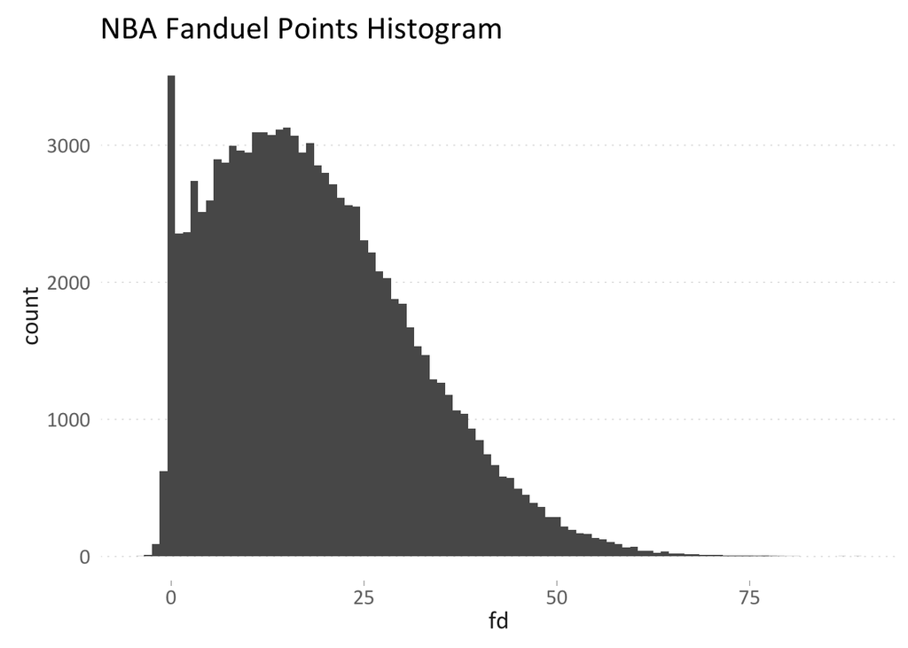

```
##    Min. 1st Qu.  Median    Mean 3rd Qu.    Max.
##   -4.00    8.60   17.10   18.75   26.90   89.00
```

For the NBA, the FD points distribution is positvely skewed. There is a large number of occurences where players score 0 FD points, despite having played more than 0 minutes in the game. This is due to players recording no statisitcs during their time on the court. The mean and median FD points for all players is 18.8 & 17.1, respectively.

Another interesting observation is that a few players actually get negative FD points, due to a high number of turnovers and lack of other offensive production.

Next, we examine a breakdown of the different player positions.

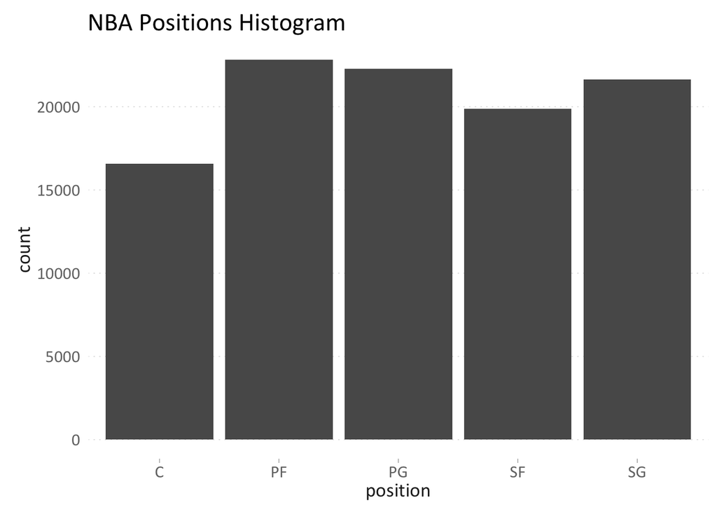

```
## Source: local data table [5 x 2]
##
## # tbl_dt [5 x 2]
##   position avg_per_game
##     <fctr>        <dbl>
## 1       PF     2.322925
## 2       PG     2.266070
## 3       SG     2.202095
## 4       SF     2.023088
## 5        C     1.685517
```

In general, there an approximately even number of players across all positions, with centers having slightly fewer numbers. On average, 1.7 centers play per game per team, compared to 2.0-2.3 players at the other positions.

Next, we examine the length of each game. Games that run for extended periods allow players to accumulate more points through increased playing time, leading to higher fantasy production.

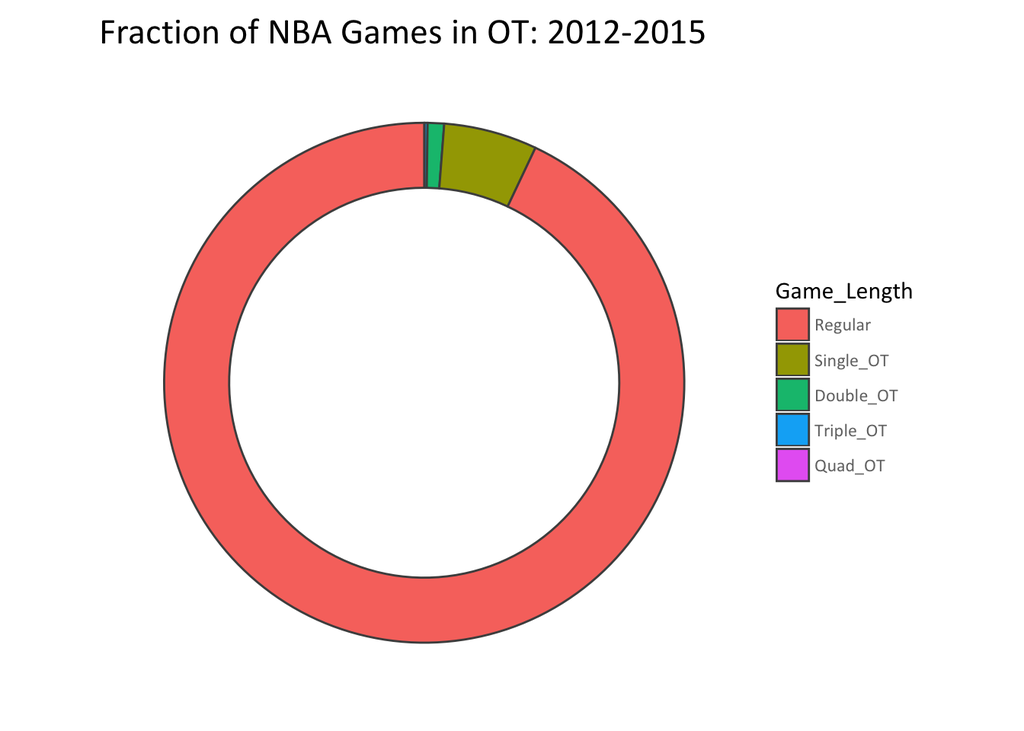

```
##    Game_Length percentage
## 1:     Quad_OT       0.02
## 2:   Triple_OT       0.19
## 3:   Double_OT       1.02
## 4:   Single_OT       5.81
## 5:     Regular      92.97
```

As shown, a very small number of games go to overtime; approximately 7%.

Rolling variables over different time windows were computed for multiple variables. These rolling variables should follow very similar distributions to the underlying, un-rolled variable. As a sanity check, the distributions of minutes and minutes over the past X games is shown below.

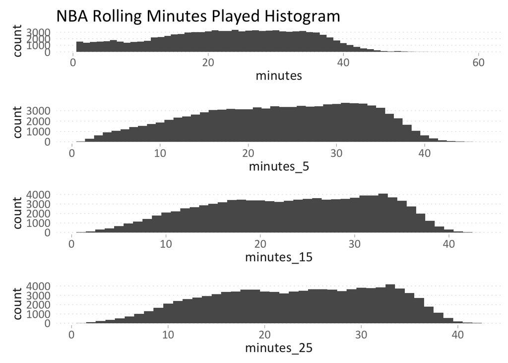

The distributions for the rolling variables look similar to the base minutes distribution. They differ in that the rolling minutes have fewer occurences of low-minute games. Low-minute games (i.e <5 min) are presumably due to cases where a player was injured mid-game, a player was brought in to close a blow-out game, or the player was pulled due to poor play. Intuitevely, these cases should not occur over consecutive games.

The formula for FD points was shown earlier. The plots below show how the distributions of relevent statistics varies between positions.

```r
player_data[, grouped_posn := ifelse(position %in% c('PG','SG','SF'),1,2)]
```

[output not shown]

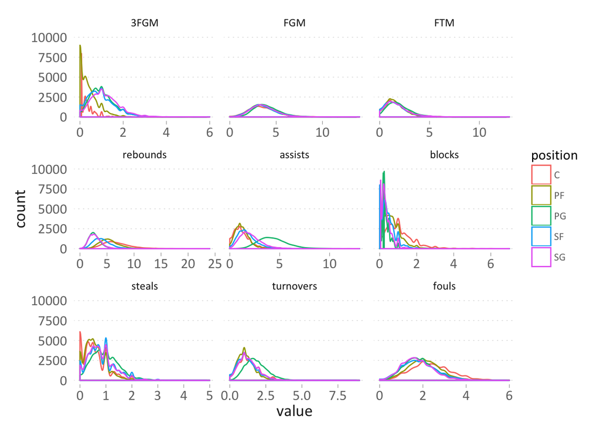

```r
base_stats = player_data[,.(`3FGM` = sum(`3FGM`)/.N , FGM = sum(FGM)/.N, FTM = sum(FTM)/.N,
                          rebounds = sum(rebounds)/.N, assists = sum(assists)/.N,
                          blocks = sum(blocks)/.N, steals = sum(steals)/.N,
                          turnovers = sum(turnovers)/.N, fouls = sum(fouls)/.N),
                         by = .(gameID, position)]

d = melt(base_stats, id.vars = c("gameID", "position"))

ggplot(d,aes(x = value, y = ..count.., colour = position)) + facet_wrap(~variable,scales = "free_x") +
  geom_density() + theme_dlin() + scale_y_continuous(limits = c(0, 10000))
```

Several conclusions can be drawn from the plot above, all intuitive to someone who has watched the sport. Starting at the top left, centers make the fewest three pointers, followed by power forwards, as indicated by their positvely skewed distributions. Field goals and free throws are similar across all positions. Point guards have the highest number of assists, whereas centers have the highest number of fouls.

## Bivariate Analysis

Through the univariate analysis, an understanding of the underlying distributions and structure of the dataset was achieved. Next, the relationships between various feature variables and a player’s FD points is explored.

A logical starting point is to look at how a player’s playing time influences his FD points.

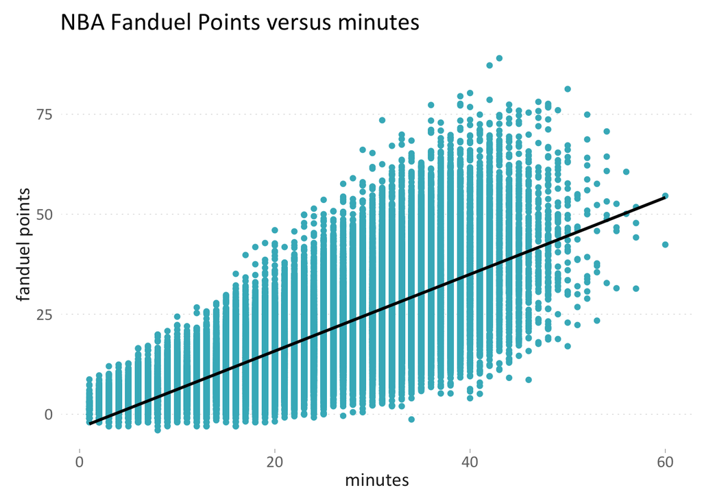

As expected, there is a very strong relationship between minutes played and FD points, R2 ~ 0.65. This is intuitive, as more time spent on the court allows players produce more, via shots, rebounds, assists etc.

Some people would argue that a more informative variable is a player’s FD points per minute, a measure of efficiency.

```r
##define player efficiency feature
player_data[, eff := fd/minutes]
```

[output not shown]

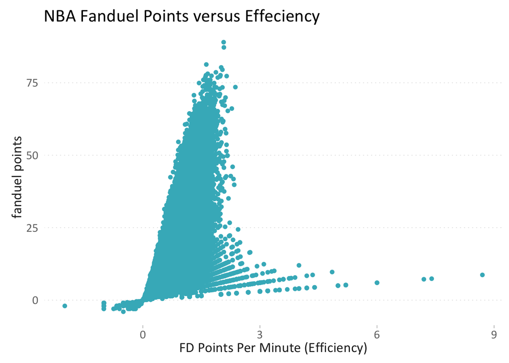

The data is relatively noisy, due to the presence of some high efficiencies.

```r
#examine some outliers
player_data[eff>3,.(gameID,player,minutes,fd,`3FGM`,FGM,FTM,rebounds,assists,blocks,steals,turnovers)][0:10]
```

```
## Source: local data table [10 x 12]
##
## # tbl_dt [10 x 12]
##                                               gameID              player
##                                               <fctr>              <fctr>
## 1             20121104-phoenix-suns-at-orlando-magic        Kyle O'Quinn
## 2      20121116-new-york-knicks-at-memphis-grizzlies      Chris Copeland
## 3        20121230-boston-celtics-at-sacramento-kings      Jarvis Varnado
## 4  20130106-oklahoma-city-thunder-at-toronto-raptors          Quincy Acy
## 5             20130111-phoenix-suns-at-brooklyn-nets   Tornike Shengelia
## 6             20130112-phoenix-suns-at-chicago-bulls Vladimir Radmanovic
## 7   20130115-los-angeles-clippers-at-houston-rockets    Patrick Beverley
## 8          20130119-cleveland-cavaliers-at-utah-jazz         Kevin Jones
## 9    20130130-charlotte-bobcats-at-san-antonio-spurs       Patrick Mills
## 10        20130222-sacramento-kings-at-atlanta-hawks          Mike Scott
## # ... with 10 more variables: minutes <int>, fd <dbl>, 3FGM <int>,
## #   FGM <int>, FTM <int>, rebounds <int>, assists <int>, blocks <int>,
## #   steals <int>, turnovers <int>
```

All of these outliers appear to be due to scenarios where players recorded multiple points, assists or rebounds in under 3 minutes; clearly un-sustainable production.

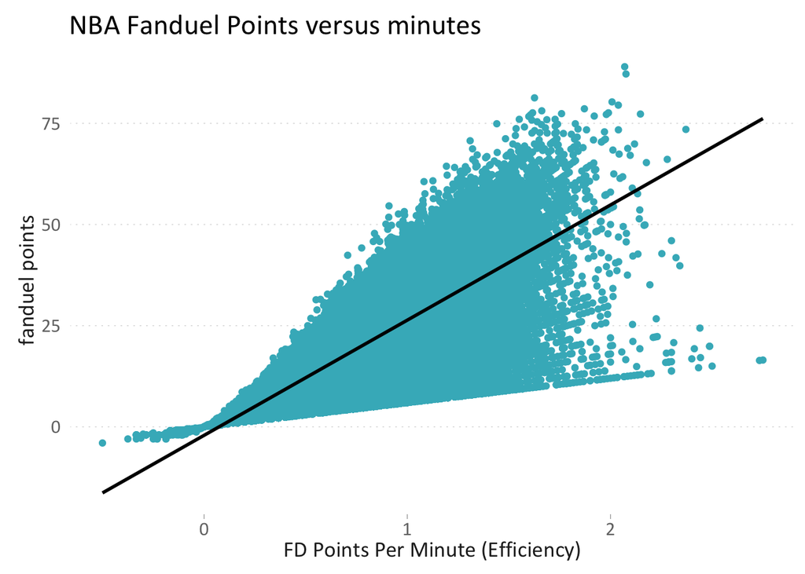

After filtering on minutes>5 and re-plotting, the positive trend between efficiency and FD points becomes more clear.

When building a predictive model, neither minutes played or efffiency will be available before the game. As a result, these variables cannot be used in a model.

[figure not shown]

```r
##corrplot - general
team_depth = player_data[, .(pos_depth=.N - 1) ,by=.(gameID,team,position)][order(gameID,team,position)]
player_data = player_data %>% inner_join(team_depth)
```

```r
##depth at position
team_depth = player_data[, .(pos_depth=.N - 1) ,by=.(gameID,team,position)][order(gameID,team,position)]
player_data = player_data %>% inner_join(team_depth)
```

[figure not shown]

```r
##INSPECT pos_depth > 5
View(player_data[pos_depth > 5]) ##-->duplicate player records
##get all dupes
View(player_data[,.(count=.N),by=.(gameID,team,player)][count>1,.(gameID,player)])
nrow(player_data[,.(count=.N),by=.(gameID,team,player)][count>1,.(gameID,player)])
```

```
## [1] 109
```

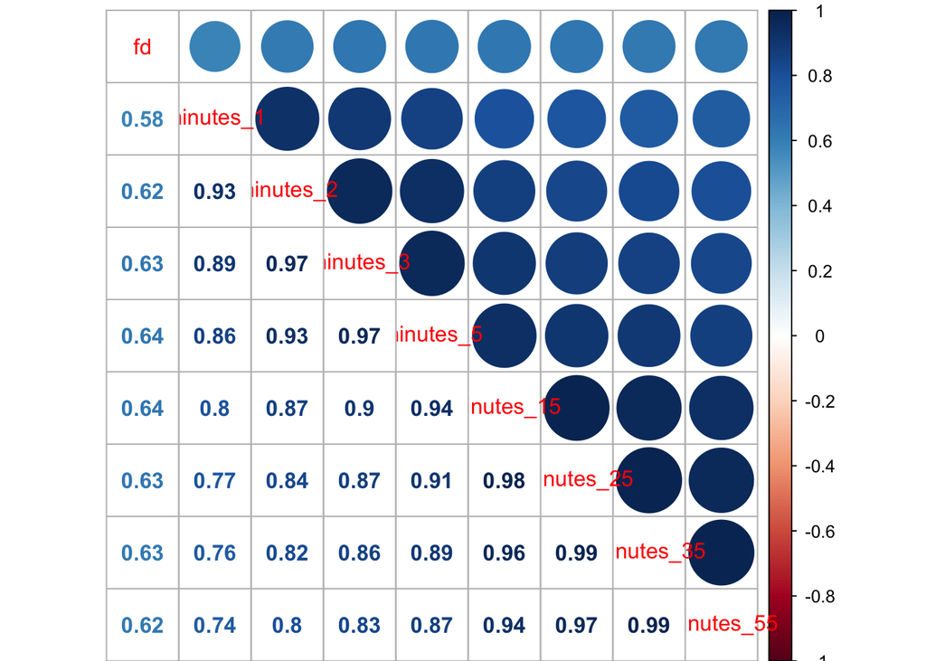

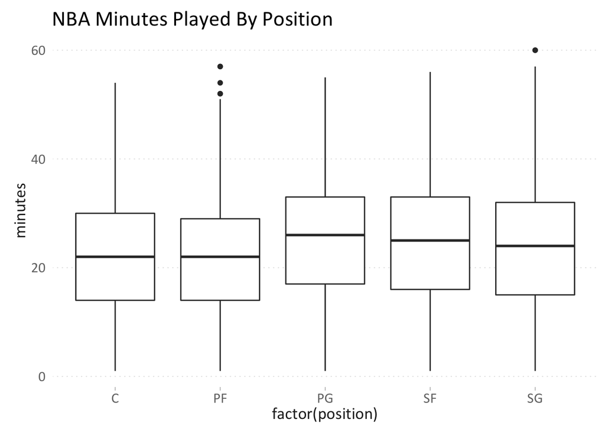

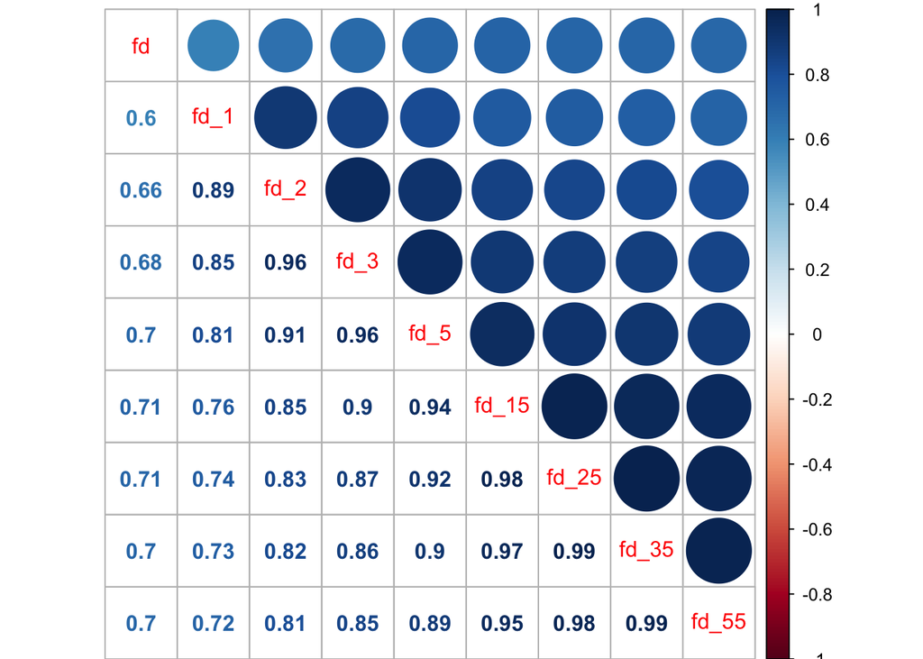

[figure not shown]

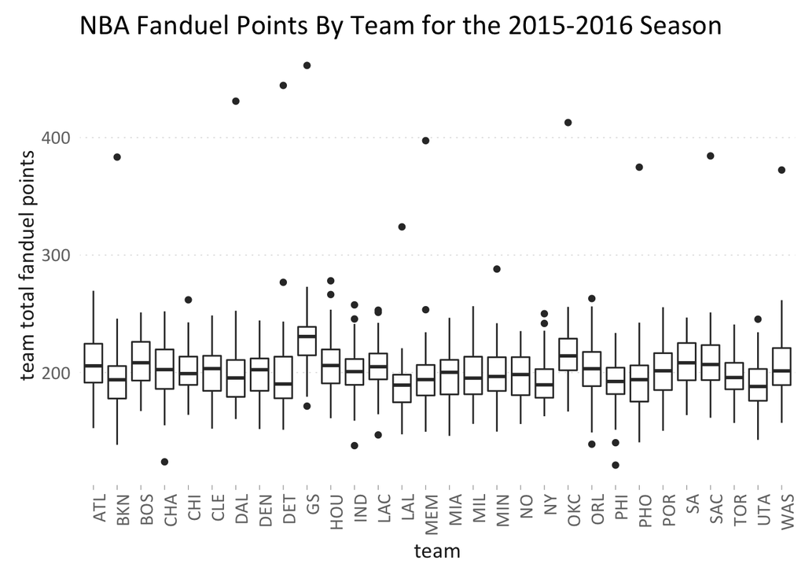

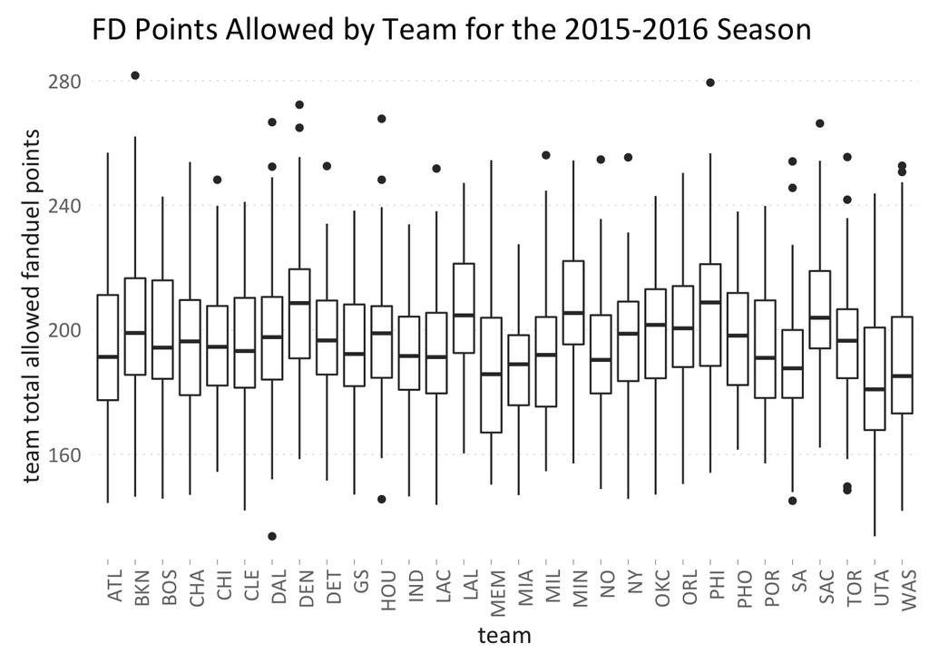